# tarea3

## Pregunta 4

Primero importaremos los datos de T8-4.DAT

```r
t8_4 <-  read.table("~/aplicada3/tarea3/T8-4.DAT", quote="\"", comment.char="")
```

Luego calcularemos la matriz muestral de covarianzas y los componentes principales

```
##              V1           V2           V3           V4           V5
## V1 0.0016299269 0.0008166676 0.0008100713 0.0004422405 0.0005139715
## V2 0.0008166676 0.0012293759 0.0008276330 0.0003868550 0.0003109431
## V3 0.0008100713 0.0008276330 0.0015560763 0.0004872816 0.0004624767
## V4 0.0004422405 0.0003868550 0.0004872816 0.0008023323 0.0004084734
## V5 0.0005139715 0.0003109431 0.0004624767 0.0004084734 0.0007587370
```

```
## Importance of components:
##                            Comp.1     Comp.2     Comp.3     Comp.4
## Standard deviation     0.05966098 0.02800461 0.02700145 0.02244063
## Proportion of Variance 0.60159252 0.13255027 0.12322412 0.08511218
## Cumulative Proportion  0.60159252 0.73414279 0.85736691 0.94247909
##                            Comp.5
## Standard deviation     0.01844812
## Proportion of Variance 0.05752091
## Cumulative Proportion  1.00000000
##
## Loadings:
##    Comp.1 Comp.2 Comp.3 Comp.4 Comp.5
## V1  0.561  0.739  0.126  0.284  0.208
## V2  0.470         0.468 -0.688 -0.281
## V3  0.547 -0.654  0.114  0.500
## V4  0.291 -0.113 -0.610 -0.438  0.582
## V5  0.284        -0.617        -0.728
```

La gráfica de codo de los componentes principales es la siguiente:

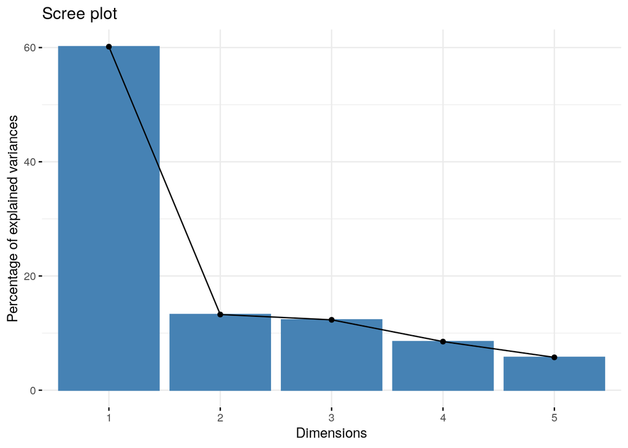

La inflexión más grande en la gráfica se da del primer al segundo componente, pero hasta el tercer componente es que se acumula almenos 80 porciento de la varianza por lo que se decide tomar los tres primeros componentes como los más significativos.

Además, si graficamos los datos en los dos primeros componentes :

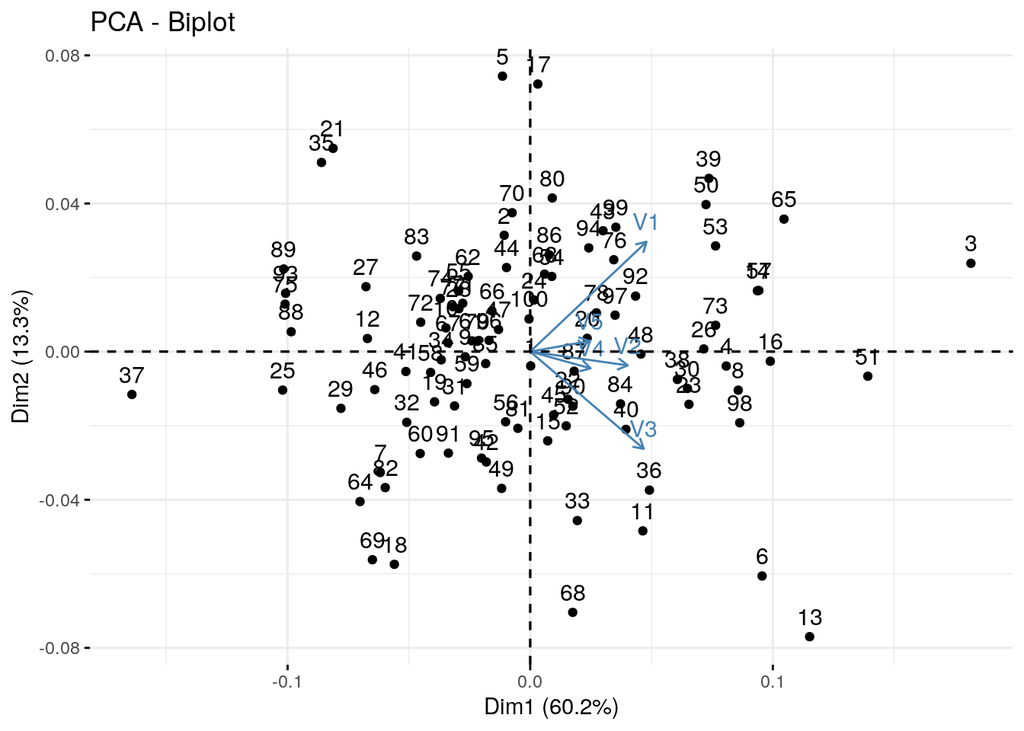

Podemos notar que el primer componente está correlacionado positivamente con las tasas de rendimiento de las 5 acciones, pero principalmente con la accion 1, 2 y 3. Así, podemos interpretar el primer componente como un promedio ponderado de las tasas de rendimiento donde se da mayor importancia a las acciones 1, 2 y 3. El segundo componente, por otro lado, se correlaciona positivamente con la primera accion y negativamente con la tercera. Interpretamos que el segundo componente es un contraste entre la primera y tercera acción

Se procederá construyendo intervalos simultáneos bonferronizados de 90% para las varianzas de los tres primeros componentes principales. Recordemos que la varianza de cada componente principal muestral es el eigenvalor muestral asociado y que se distribuye aproximadamente normal con media igual al eigenvalor poblacional y varianza $2\frac{\lambda_i^{2}}{n}$. Así podemos construir el intervalo basado en la distribución normal y ajustamos el nivel de confianza para que conjuntamente se tenga 90%

```
##       Comp.1       Comp.2       Comp.3
## 0.0035594328 0.0007842580 0.0007290781
```

```
##
## Intervalo para  0.003559433  : ( 0.002736024 0.005091822 )
## Intervalo para  0.000784258  : ( 0.0006028344 0.001121893 )
## Intervalo para  0.0007290781  : ( 0.0005604194 0.001042957 )
```

De las gráficas anteriores podemos conluir que sí es posible resumir la variabilidad en menos de 5 dimensiones, pues los tres primeros componentes acumulan más del 80% de varianza y aunque se pierde algo de información, la reducción de dimensionalidad trae beneficios de interpretación.

Ahora repetiremos el análisis para datos de acciones de 2017

Cargamos los datos

```r
datos17 <- read.csv("~/aplicada3/tarea3/AccionesBMV2017.csv")
```

Quitamos las fechas

```r
datos17 <- datos17[ , 2:7]
```

Luego calcularemos la matriz muestral de covarianzas y los componentes principales

```
##                   MSFT  LIVERPOLC1    GFINBURO      GCARSOA1    ELEKTRA
## MSFT       15820.27636 -991.879329  73.0665844  -906.0599340  7363.9230
## LIVERPOLC1  -991.87933  125.259395  -3.3355626    33.8254532   388.9607
## GFINBURO      73.06658   -3.335563   1.6009811    -5.7572055   164.9255
## GCARSOA1    -906.05993   33.825453  -5.7572055    81.8708899 -1314.8685
## ELEKTRA     7363.92301  388.960675 164.9254956 -1314.8684958 44132.7262
## BSMX        -168.54550   26.168865   0.5263259    -0.6937791   355.3047
##                    BSMX
## MSFT       -168.5455025
## LIVERPOLC1   26.1688645
## GFINBURO      0.5263259
## GCARSOA1     -0.6937791
## ELEKTRA     355.3046793
## BSMX          8.1087306
```

```
## Importance of components:
##                             Comp.1      Comp.2       Comp.3       Comp.4
## Standard deviation     214.0139664 118.6188866 6.8127551426 3.1491423700
## Proportion of Variance   0.7642564   0.2347808 0.0007744625 0.0001654777
## Cumulative Proportion    0.7642564   0.9990371 0.9998116080 0.9999770857
##                              Comp.5       Comp.6
## Standard deviation     9.170230e-01 7.296082e-01
## Proportion of Variance 1.403186e-05 8.882481e-06
## Cumulative Proportion  9.999911e-01 1.000000e+00
##
## Loadings:
##            Comp.1 Comp.2 Comp.3 Comp.4 Comp.5 Comp.6
## MSFT        0.238  0.967
## LIVERPOLC1                0.978  0.126 -0.101 -0.104
## GFINBURO                         0.120  0.608 -0.784
## GCARSOA1                 -0.125  0.983         0.109
## ELEKTRA     0.971 -0.238
## BSMX                      0.143         0.785  0.602
```

La gráfica de codo de los componentes principales es la siguiente:

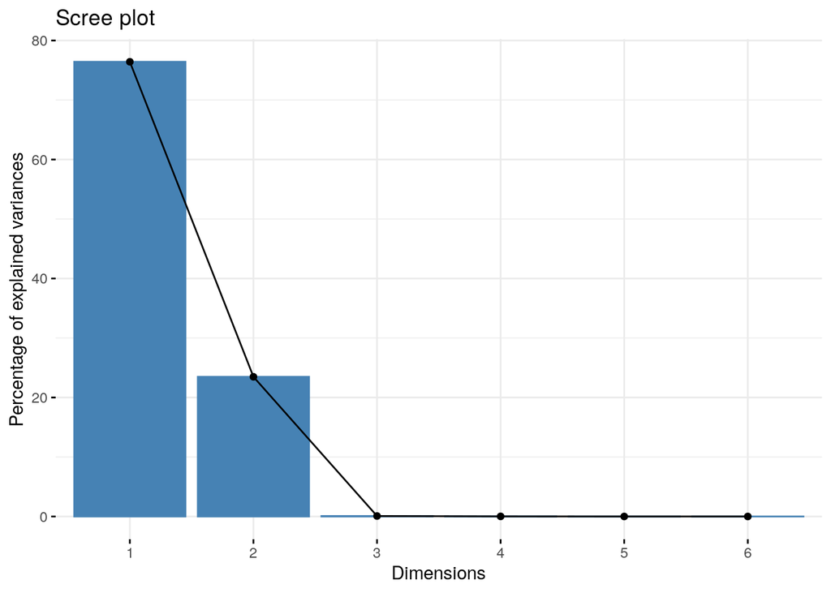

La inflexión más grande en la gráfica se da del primer al segundo componente, pero hasta el segundo componente es que se acumula almenos 80 porciento de la varianza por lo que se decide tomar los dos primeros componentes

De las cargas podemos ver que el primer componente es un promedio ponderado de MSFT y ELEKTRA, el cual acumula 76% de la varianza. El segundo componente es un contraste entre las mismas variables y acumula 23% de la varianza. Conjuntamente, los componentes acumulan 99% de la varianza.

Se procederá construyendo intervalos simultáneos bonferronizados de 90% para las varianzas de los tres primeros componentes principales.

```
##      Comp.1      Comp.2      Comp.3
## 45801.97780 14070.44026    46.41363
```

```
##
## Intervalo para  45801.98  : ( 38490.4 56542.76 )
## Intervalo para  14070.44  : ( 11824.31 17370.03 )
## Intervalo para  46.41363  : ( 39.00441 57.29785 )
```

De las gráficas anteriores podemos conluir que sí es posible resumir la variabilidad en menos de 5 dimensiones, pues los dos primeros componentes acumulan 99% de varianza.

## Pregunta 6

Primero importaremos los datos de T1-10.DAT

```r
t1_10 <- read.table("~/aplicada3/tarea3/T1-10.DAT", quote="\"", comment.char="")
colnames(t1_10)<- c("Raza","PVenta","YrHgt","FtFreBody","PrctFFB","Frame","BkFat","SaleHt","SaleWt")
```

y descartamos las dos primeras variables

```r
t1_10 <- t1_10[, 3:9]
```

Los siguientes incisos se harán para los componentes principales basados en la matriz de covarianza como en la matriz de correlaciones

1. Determinemos el número de componentes que resumen adecuadamente la variabilidad

Usando la covarianza tenemos:

```
## Importance of components:
##                             Comp.1     Comp.2       Comp.3       Comp.4
## Standard deviation     142.5090460 69.3580156 2.3146777818 1.8090529826
## Proportion of Variance   0.8081979  0.1914371 0.0002132131 0.0001302373
## Cumulative Proportion    0.8081979  0.9996351 0.9998482652 0.9999785025
##                              Comp.5       Comp.6       Comp.7
## Standard deviation     6.801921e-01 2.703318e-01 6.678305e-02
## Proportion of Variance 1.841179e-05 2.908220e-06 1.774865e-07
## Cumulative Proportion  9.999969e-01 9.999998e-01 1.000000e+00
##
## Loadings:
##           Comp.1 Comp.2 Comp.3 Comp.4 Comp.5 Comp.6 Comp.7
## YrHgt                    0.286  0.609  0.536  0.510
## FtFreBody  0.487  0.873
## PrctFFB                  0.904 -0.425
## Frame                    0.133  0.311  0.391 -0.855
## BkFat                                                0.999
## SaleHt                   0.284  0.593 -0.749
## SaleWt     0.873 -0.487
```

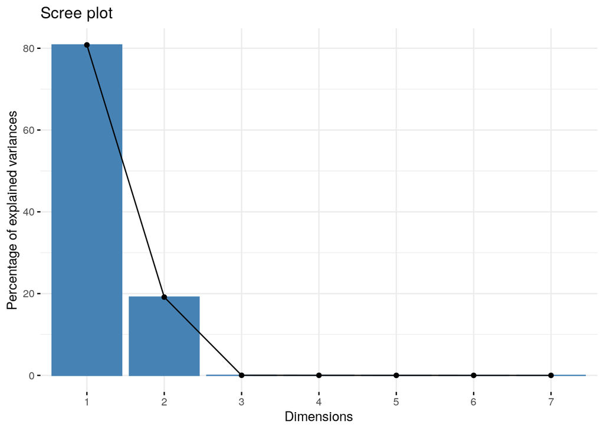

Podemos ver la inflexión muy marcada del segundo al tercer componente. Los primeros dos componentes acumulan más del 95% de la variabilidad. Aunque podriamos elegir sólo el primer componente (ya que acumula 80% de variabilidad) preferimos optar por el criterio de la gráfica de codo y elegimos las dos primeras componentes.

Usando la correlación:

```
## Importance of components:
##                           Comp.1    Comp.2    Comp.3    Comp.4    Comp.5
## Standard deviation     2.0299502 1.1563431 0.8610357 0.6491727 0.4310521
## Proportion of Variance 0.5886711 0.1910185 0.1059118 0.0602036 0.0265437
## Cumulative Proportion  0.5886711 0.7796896 0.8856014 0.9458050 0.9723487
##                            Comp.6      Comp.7
## Standard deviation     0.38275628 0.216925572
## Proportion of Variance 0.02092891 0.006722386
## Cumulative Proportion  0.99327761 1.000000000
##
## Loadings:
##           Comp.1 Comp.2 Comp.3 Comp.4 Comp.5 Comp.6 Comp.7
## YrHgt      0.450         0.416  0.113                0.775
## FtFreBody  0.412 -0.130 -0.450  0.247 -0.719  0.177
## PrctFFB    0.356  0.316 -0.568  0.315  0.579 -0.128
## Frame      0.434         0.452  0.243  0.143  0.434 -0.582
## BkFat     -0.187 -0.715         0.618  0.160 -0.208
## SaleHt     0.453 -0.101  0.177 -0.216 -0.110 -0.799 -0.237
## SaleWt     0.270 -0.601 -0.253 -0.582  0.291  0.277
```

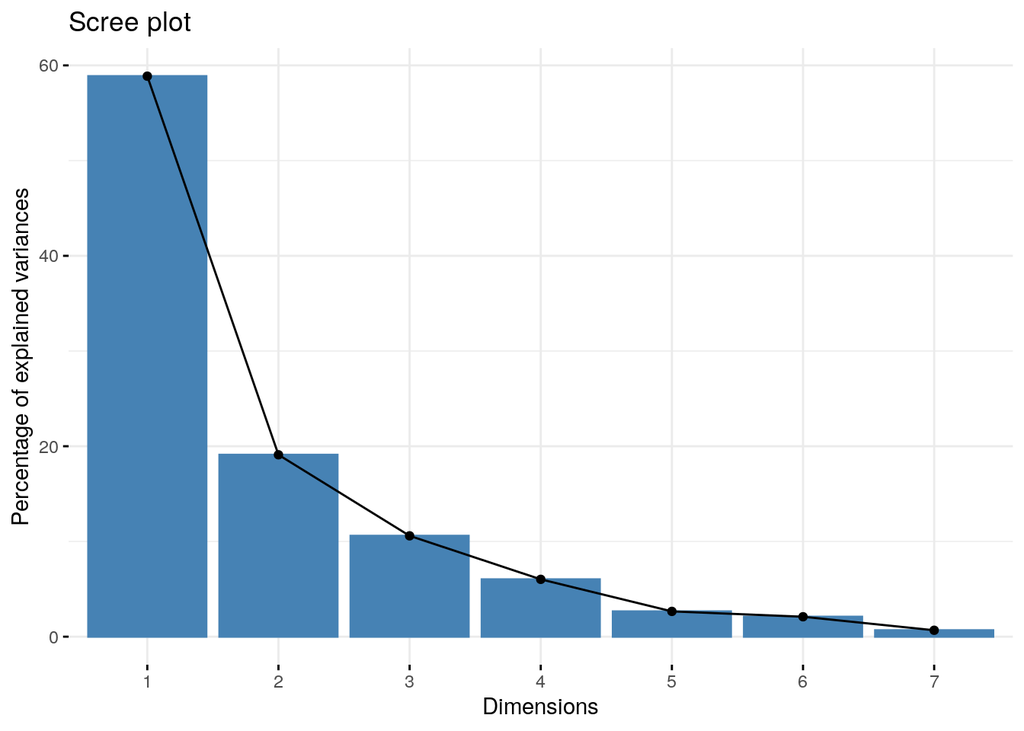

Aquí la gráfica muestra una curva más suave, y es hasta el tercer componente que se acumula almenos 80% de la variabilidad, por lo que en este caso elegimos los tres primeros componentes para resumir la variabilidad.

2. Interpretación de los componentes principales

# Covarianza

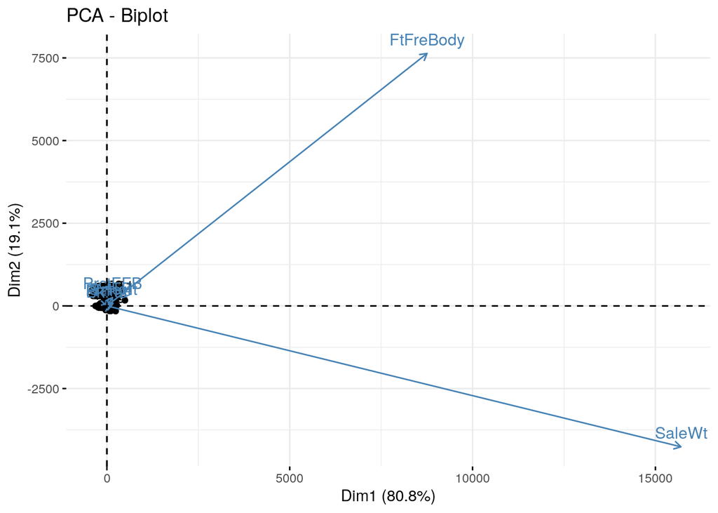

De la gráfica y de las cargas podemos ver que el primer componente es un promedio ponderado del cuerpo libre de grasa y de peso de ventas, mientras que el segundo es un contraste entre las mismas variables

# Correlacion

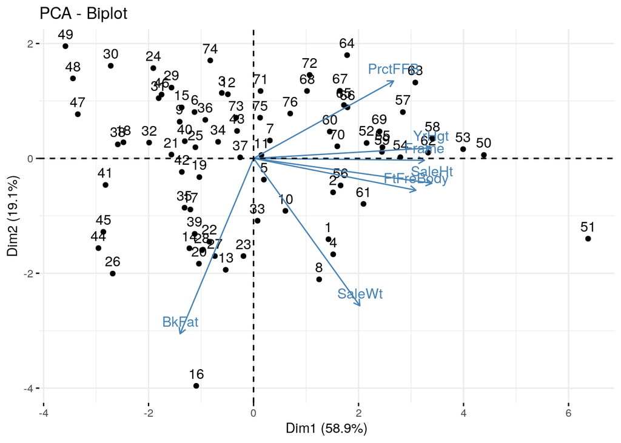

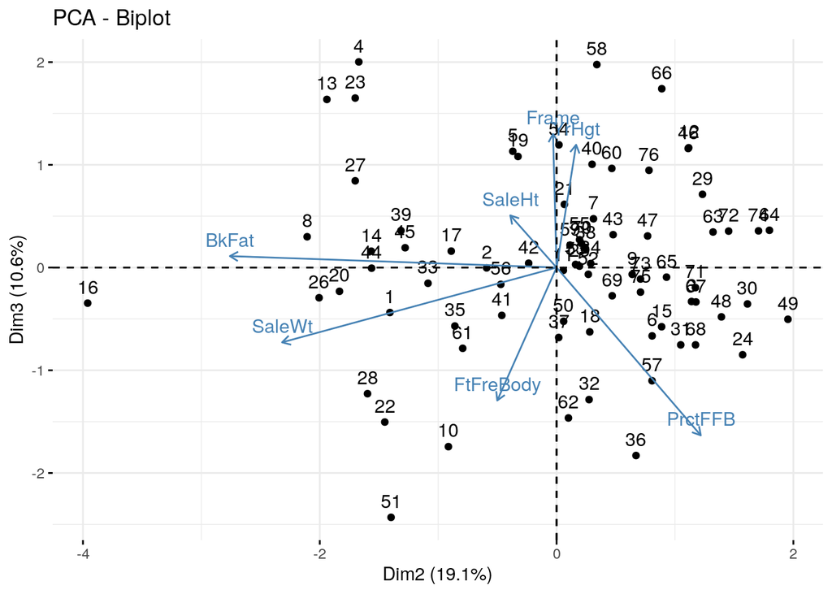

De las gráficas y las cargas notamos que el primer componente es un promedio ponderado donde todas las variables tienen pesos significativos y la grasa trasera tiene signo negativo. El segundo componente es un contraste entre porcentaje del cuerpo libre de grasa con grasa trasera y peso de venta. El tercer componente contrasta medicion al hombro y porcentaje del cuerpo libre de grasa

Sí es posible desarrollar un índice “Configuración del cuerpo” pues el primer componente principal usando la correlación es una ponderación de las variables que determinan la configuración del cuerpo del animal y cuenta para una buena proporcion de la varianza ( aprox 60% )

4. Outliers

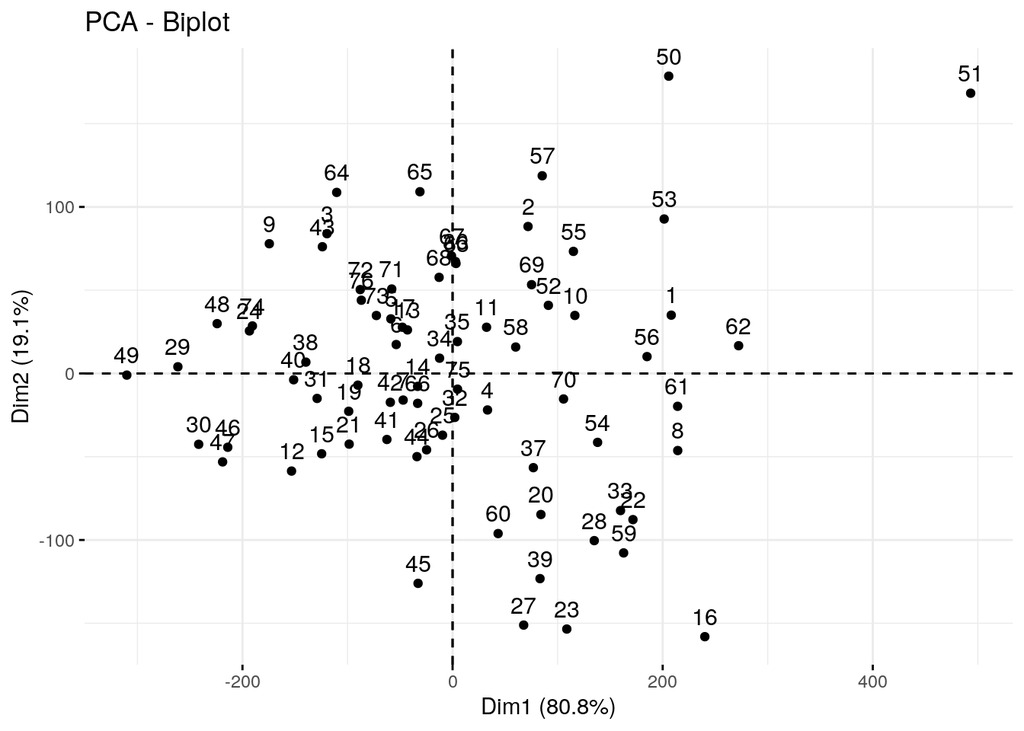

Considerando los componentes basados en la covarianza vemos que hay dos candidatos a outliers la observación 50 y la 51

5. Ahora evaluaremos si los dotas son normales. Para esto mostraremos las gráficas QQ de cada variable y la transformacion que le aplicaremos

# YrHgt

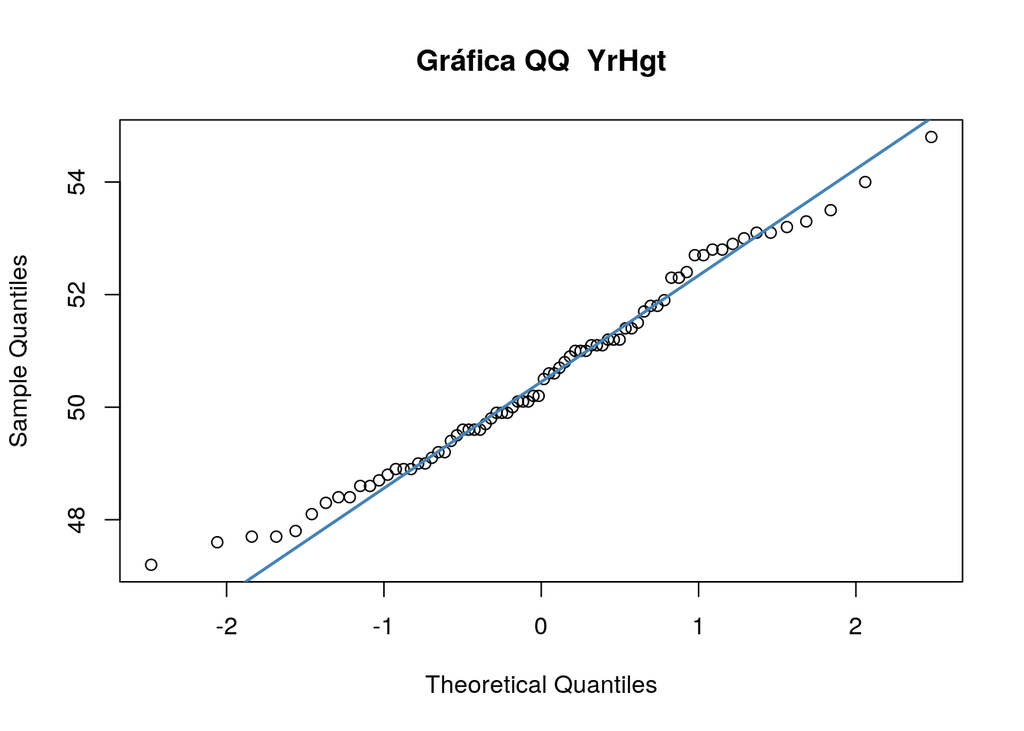

Parece ser aproximadamente normal

# FtFreBody

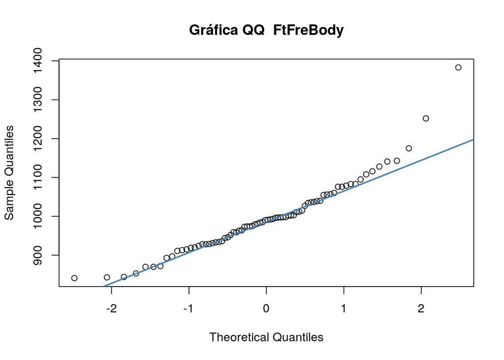

Aplicando la transformacion logaritmo

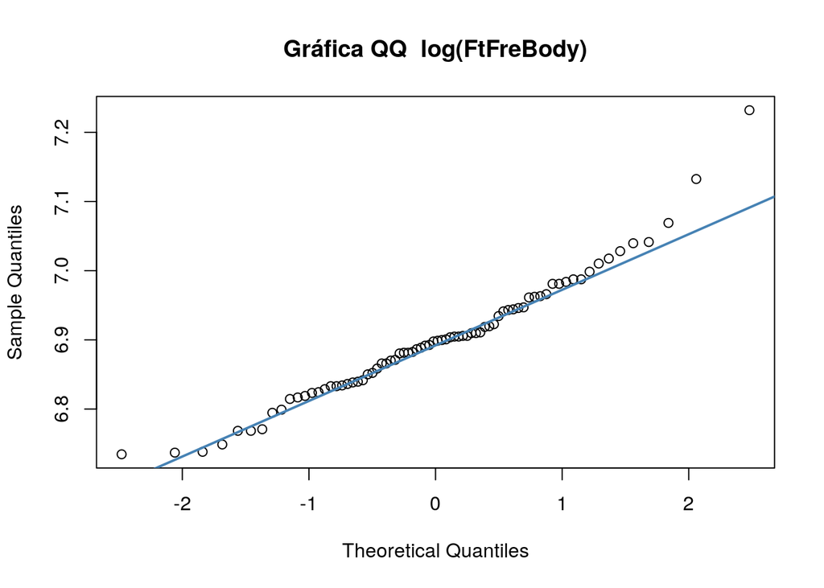

# PrctFFB

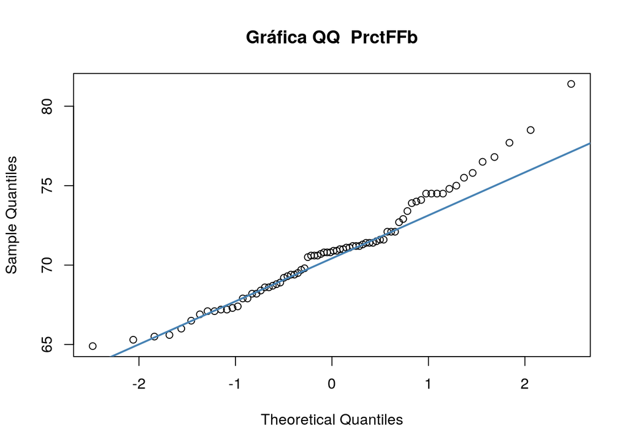

Utilizando el recíproco:

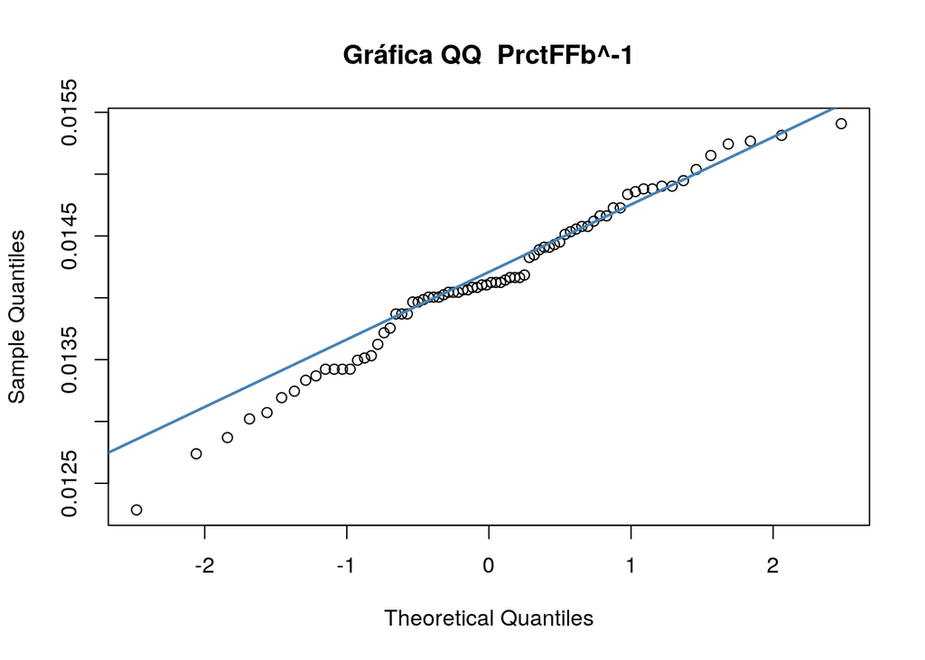

# Frame y BkFat

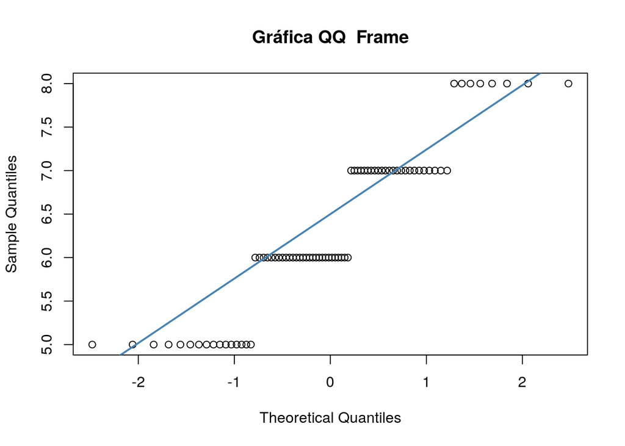

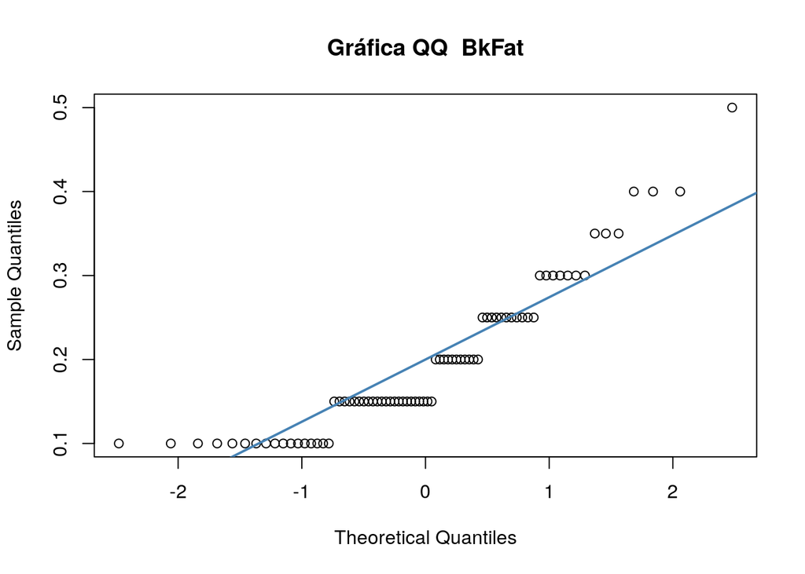

Como podemos ver, estas variables tienen mediciones discretas por lo que no se aplicaron transformaciones.

# SaleHt

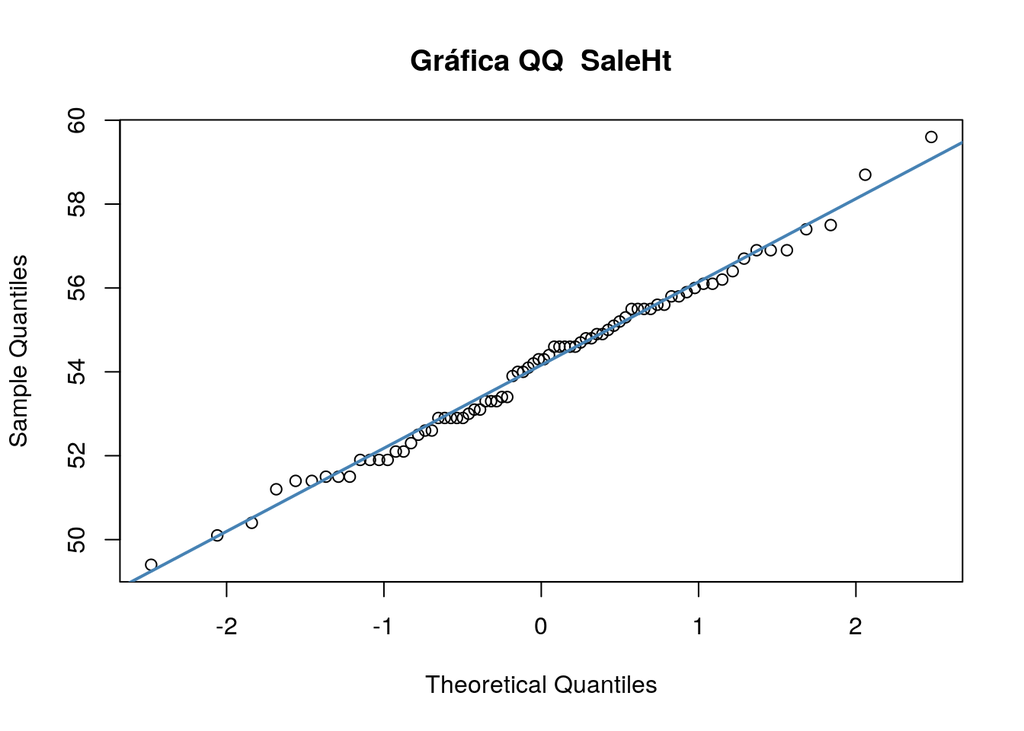

Parece cumplir normalidad

# SaleWt

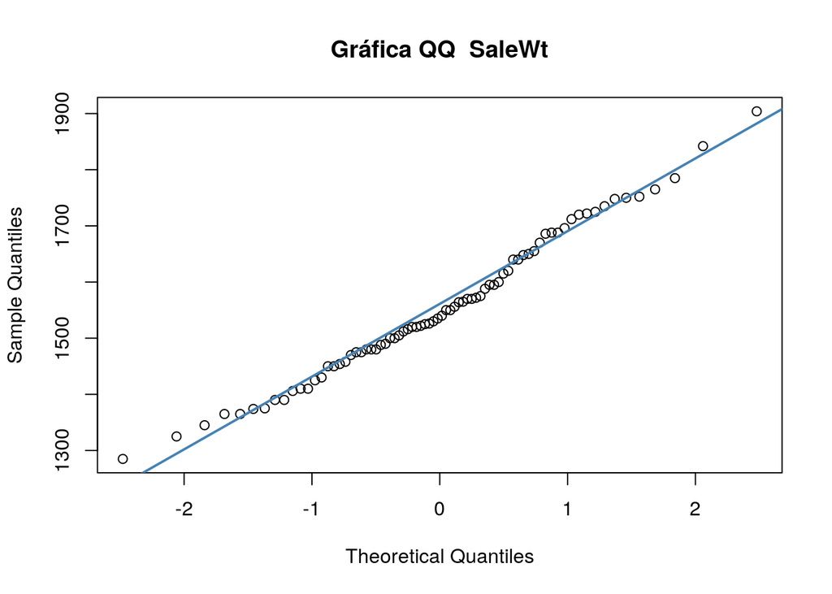

Parece cumplir normalidad

Pasamos a transformar nuestros datos

```r
t1_10$FtFreBody <- log(t1_10$FtFreBody)
t1_10$PrctFFB <- t1_10$PrctFFB^-1
```

Los siguientes incisos se harán para los componentes principales basados en la matriz de covarianza como en la matriz de correlaciones

1. Determinemos el número de componentes que resumen adecuadamente la variabilidad

Usando la covarianza tenemos:

```
## Importance of components:
##                             Comp.1       Comp.2       Comp.3       Comp.4
## Standard deviation     128.9601993 2.3343592074 6.816079e-01 2.715550e-01
## Proportion of Variance   0.9996396 0.0003275423 2.792552e-05 4.432487e-06
## Cumulative Proportion    0.9996396 0.9999670948 9.999950e-01 9.999995e-01
##                              Comp.5       Comp.6       Comp.7
## Standard deviation     7.466704e-02 5.940132e-02 3.961602e-04
## Proportion of Variance 3.351120e-07 2.120920e-07 9.433520e-12
## Cumulative Proportion  9.999998e-01 1.000000e+00 1.000000e+00
##
## Loadings:
##           Comp.1 Comp.2 Comp.3 Comp.4 Comp.5 Comp.6 Comp.7
## YrHgt             0.663  0.546  0.510
## FtFreBody                             -0.208  0.978
## PrctFFB                                              1.000
## Frame             0.333  0.396 -0.854
## BkFat                                  0.976  0.208
## SaleHt            0.669 -0.738
## SaleWt     1.000
```

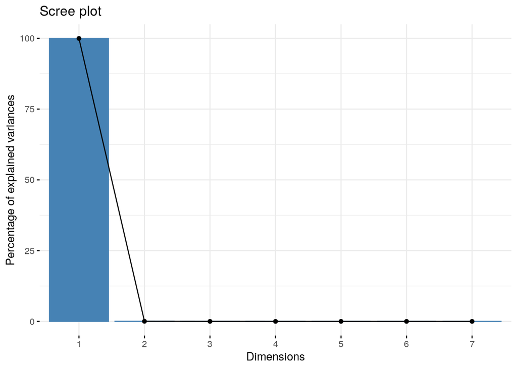

Podemos ver la inflexión muy marcada del primero al tercer componente. El primer componente (que coincide con la variable original SaleWt) acumula 99% de la variabilidad

Usando la correlación:

```
## Importance of components:
##                           Comp.1    Comp.2    Comp.3     Comp.4     Comp.5
## Standard deviation     2.0270642 1.1642112 0.8530403 0.64646144 0.44342636
## Proportion of Variance 0.5869984 0.1936268 0.1039540 0.05970177 0.02808956
## Cumulative Proportion  0.5869984 0.7806253 0.8845792 0.94428101 0.97237057
##                            Comp.6      Comp.7
## Standard deviation     0.38252700 0.216977175
## Proportion of Variance 0.02090384 0.006725585
## Cumulative Proportion  0.99327442 1.000000000
##
## Loadings:
##           Comp.1 Comp.2 Comp.3 Comp.4 Comp.5 Comp.6 Comp.7
## YrHgt      0.451         0.417  0.105                0.775
## FtFreBody  0.412 -0.133 -0.444  0.260 -0.722  0.163
## PrctFFB   -0.351 -0.339  0.560 -0.325 -0.573  0.119
## Frame      0.435         0.454  0.235  0.144  0.435 -0.582
## BkFat     -0.189 -0.708         0.621  0.176 -0.209
## SaleHt     0.454 -0.105  0.169 -0.220        -0.801 -0.236
## SaleWt     0.269 -0.595 -0.281 -0.571  0.295  0.281
```

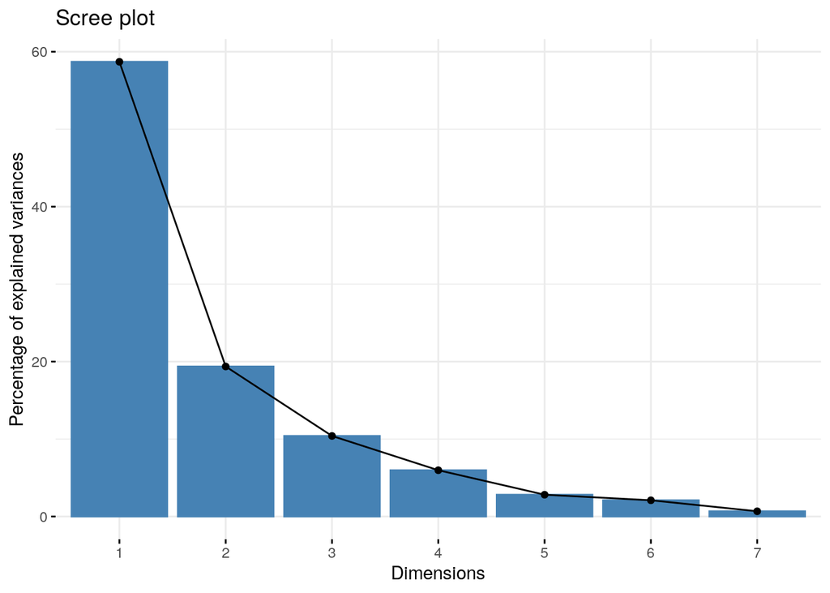

Aquí la gráfica muestra una curva más suave, y es hasta el tercer componente que se acumula almenos 80% de la variabilidad, por lo que en este caso elegimos los tres primeros componentes para resumir la variabilidad.

2. Interpretación de los componentes principales

# Covarianza

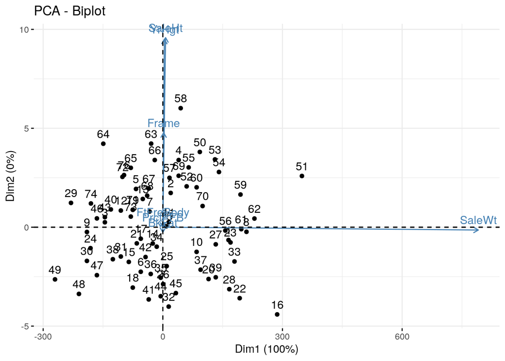

De la gráfica y de las cargas podemos ver que el primer componente coincide con SaleWt

# Correlacion

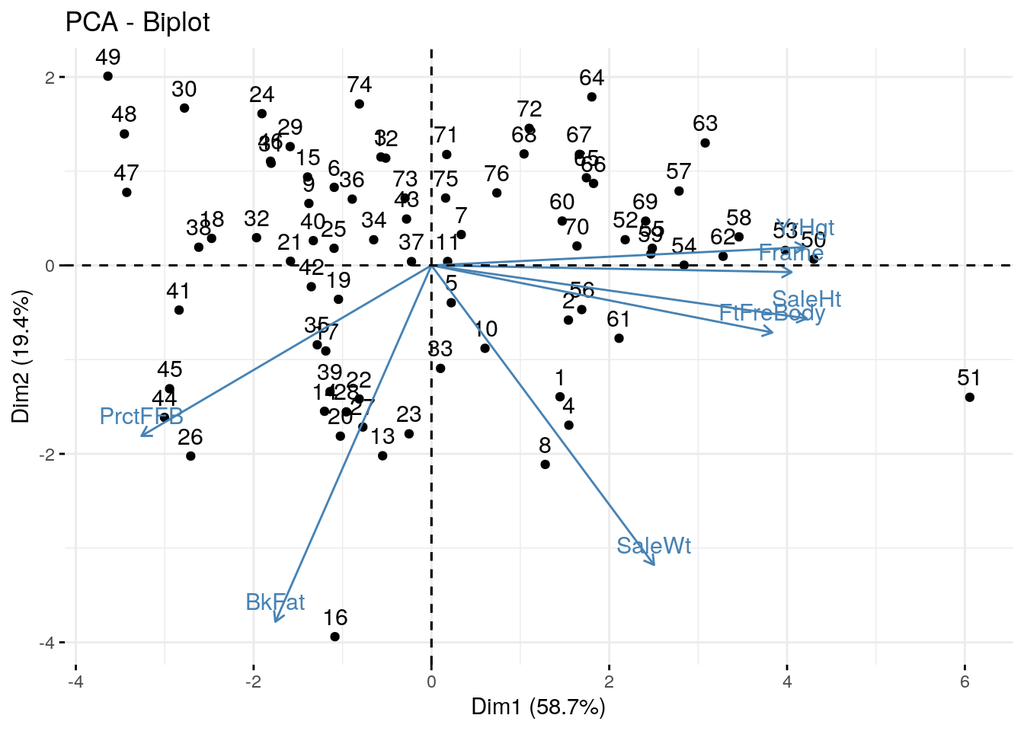

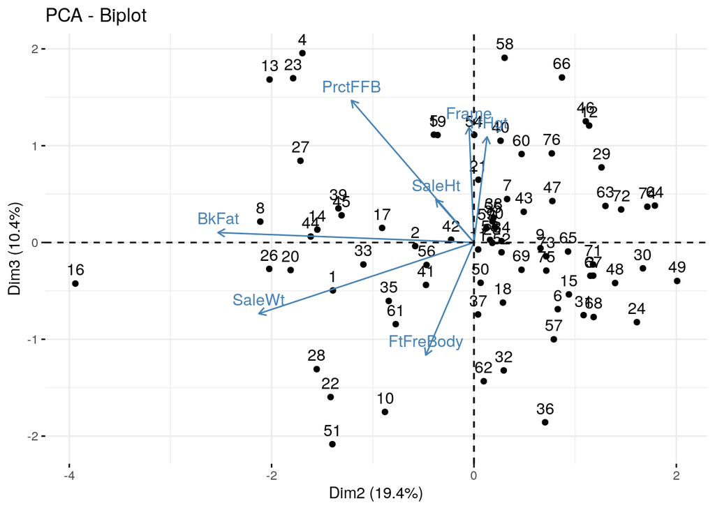

De las gráficas y las cargas notamos que el primer componente es un contraste entre YrHgt, FtFreBody, Frame , SaleHt y SaleWt con las variables restantes. El segundo componente es un promedio ponderado con signo negativo de las variables y el tercer componente es un contraste.

No es claro como crear un indice pues los componentes principales usando la covarianza es sólo una variable y usando la correlación son contrastes.

## Pregunta 10

Primero carguemos los datos del archivo T7-5.DAT

```r
t7_5 <- read.table("~/aplicada3/tarea3/T7-5.DAT", quote="\"", comment.char="")
colnames(t7_5) <- c("tasa_carga", "tasa_descarga", "prof_descarga", "temperatura", "voltaje_fin", "ciclos")
```

Primero realizaremos una regresión con todas las variables

```
##
## Call:
## lm(formula = log(ciclos) ~ ., data = t7_5)
##
## Residuals:
##     Min      1Q  Median      3Q     Max
## -2.0932 -0.6697  0.2702  0.7417  1.3986
##
## Coefficients:
##                Estimate Std. Error t value Pr(>|t|)
## (Intercept)   -63.68324   51.17800  -1.244 0.233802
## tasa_carga     -0.45925    0.54926  -0.836 0.417124
## tasa_descarga  -0.32668    0.17615  -1.855 0.084834 .
## prof_descarga  -0.01113    0.01699  -0.655 0.522932
## temperatura     0.11577    0.02499   4.633 0.000387 ***
## voltaje_fin    33.81176   25.58798   1.321 0.207560
## ---
## Signif. codes:  0 '***' 0.001 '**' 0.01 '*' 0.05 '.' 0.1 ' ' 1
##
## Residual standard error: 1.07 on 14 degrees of freedom
## Multiple R-squared:  0.6633, Adjusted R-squared:  0.543
## F-statistic: 5.515 on 5 and 14 DF,  p-value: 0.005184
```

Como podemos ver, sólo uno de los regresores (temperatura) tiene un coeficiente significativo. Para contrastar, construiremos el modelo que tiene a temperatura como el único regresor.

```
##
## Call:
## lm(formula = log(ciclos) ~ temperatura, data = t7_5)
##
## Residuals:
##     Min      1Q  Median      3Q     Max
## -2.2241 -0.6308  0.2063  0.7896  1.4395
##
## Coefficients:
##             Estimate Std. Error t value Pr(>|t|)
## (Intercept)  1.77769    0.56596   3.141 0.005649 **
## temperatura  0.11395    0.02597   4.388 0.000355 ***
## ---
## Signif. codes:  0 '***' 0.001 '**' 0.01 '*' 0.05 '.' 0.1 ' ' 1
##
## Residual standard error: 1.13 on 18 degrees of freedom
## Multiple R-squared:  0.5169, Adjusted R-squared:   0.49
## F-statistic: 19.26 on 1 and 18 DF,  p-value: 0.0003546
```

Por último, para definir el subconjunto de regresores también podemos utilizar el método stepAIC de la libreria MASS :

```
## Start:  AIC=7.58
## log(ciclos) ~ tasa_carga + tasa_descarga + prof_descarga + temperatura +
##     voltaje_fin
##
##                 Df Sum of Sq    RSS     AIC
## - prof_descarga  1    0.4917 16.523  6.1810
## - tasa_carga     1    0.8006 16.832  6.5514
## <none>                       16.032  7.5768
## - voltaje_fin    1    1.9995 18.031  7.9275
## - tasa_descarga  1    3.9387 19.971  9.9705
## - temperatura    1   24.5815 40.613 24.1673
##
## Step:  AIC=6.18
## log(ciclos) ~ tasa_carga + tasa_descarga + temperatura + voltaje_fin
##
##                 Df Sum of Sq    RSS     AIC
## - tasa_carga     1    0.5160 17.039  4.7960
## <none>                       16.523  6.1810
## - voltaje_fin    1    1.9690 18.492  6.4327
## + prof_descarga  1    0.4917 16.032  7.5768
## - tasa_descarga  1    4.5731 21.097  9.0675
## - temperatura    1   24.3922 40.916 22.3156
##
## Step:  AIC=4.8
## log(ciclos) ~ tasa_descarga + temperatura + voltaje_fin
##
##                 Df Sum of Sq    RSS     AIC
## <none>                       17.039  4.7960
## - voltaje_fin    1    1.9747 19.014  4.9890
## + tasa_carga     1    0.5160 16.523  6.1810
## + prof_descarga  1    0.2071 16.832  6.5514
## - tasa_descarga  1    4.3410 21.380  7.3349
## - temperatura    1   25.8384 42.878 21.2524
```

```
##
## Call:
## lm(formula = log(ciclos) ~ tasa_descarga + temperatura + voltaje_fin,
##     data = t7_5)
##
## Residuals:
##     Min      1Q  Median      3Q     Max
## -1.7954 -0.7995  0.2129  0.6183  1.4406
##
## Coefficients:
##                Estimate Std. Error t value Pr(>|t|)
## (Intercept)   -64.43215   49.34720  -1.306 0.210121
## tasa_descarga  -0.33647    0.16666  -2.019 0.060573 .
## temperatura     0.11754    0.02386   4.926 0.000152 ***
## voltaje_fin    33.59708   24.67298   1.362 0.192161
## ---
## Signif. codes:  0 '***' 0.001 '**' 0.01 '*' 0.05 '.' 0.1 ' ' 1
##
## Residual standard error: 1.032 on 16 degrees of freedom
## Multiple R-squared:  0.6421, Adjusted R-squared:  0.575
## F-statistic: 9.568 on 3 and 16 DF,  p-value: 0.0007419
```

Ahora graficaremos los residuales de nuestro modelo

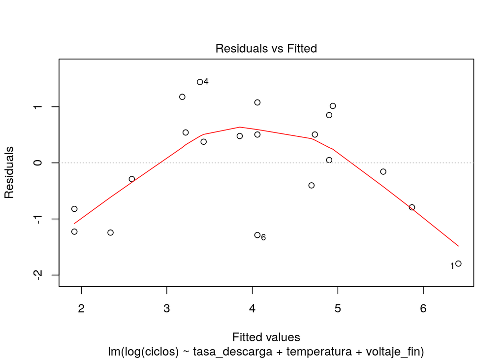

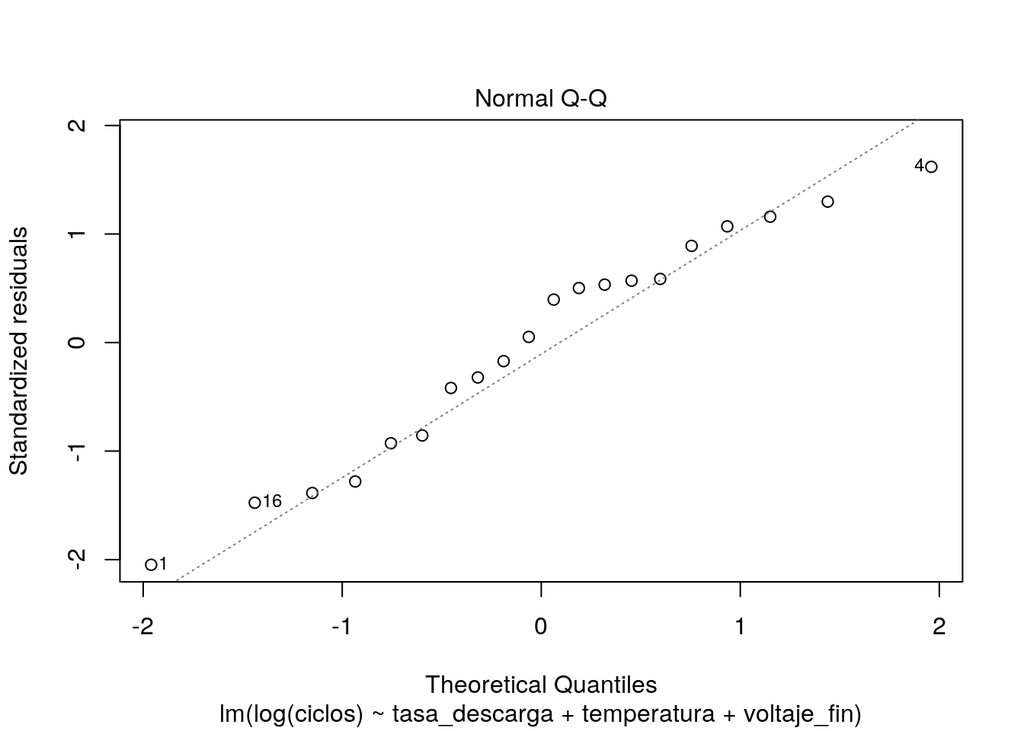

De las gráficas no notamos una patente desviación de la normalidad. En la gráfica QQ hay una leve desviación en el centro de la gráfica.

Ahora calcularemos los componentes principales:

```
## Importance of components:
##                            Comp.1    Comp.2      Comp.3       Comp.4
## Standard deviation     15.0991154 9.6968574 1.361404508 0.4356009798
## Proportion of Variance  0.7035314 0.2901633 0.005719458 0.0005855422
## Cumulative Proportion   0.7035314 0.9936947 0.999414188 0.9999997301
##                              Comp.5
## Standard deviation     9.351386e-03
## Proportion of Variance 2.698562e-07
## Cumulative Proportion  1.000000e+00
##
## Loadings:
##               Comp.1 Comp.2 Comp.3 Comp.4 Comp.5
## tasa_carga                          1.000
## tasa_descarga               -1.000
## prof_descarga -0.997
## temperatura          -0.997
## voltaje_fin                               -1.000
```

Notamos que la primer componente acumula 70% de la varianza. También se puede ver que las cargas (los eigenvalores de la matriz de covarianza) son los vectores canónicos, por lo que el método de componentes principales no está modificando las variables.

Así, hacer la regresión con la primer componente principal es equivalente a hacer la regresión con la variable prof_descarga:

```
##
## Call:
## lm(formula = log(ciclos) ~ prof_descarga, data = t7_5)
##
## Residuals:
##     Min      1Q  Median      3Q     Max
## -3.2082 -0.5946  0.4870  1.1304  1.8481
##
## Coefficients:
##                Estimate Std. Error t value Pr(>|t|)
## (Intercept)    4.443016   1.555508   2.856   0.0105 *
## prof_descarga -0.007053   0.024071  -0.293   0.7729
## ---
## Signif. codes:  0 '***' 0.001 '**' 0.01 '*' 0.05 '.' 0.1 ' ' 1
##
## Residual standard error: 1.622 on 18 degrees of freedom
## Multiple R-squared:  0.004747,   Adjusted R-squared:  -0.05054
## F-statistic: 0.08586 on 1 and 18 DF,  p-value: 0.7729
```

Cómo podemos ver, la $R^2$ empeoró considerablemente. Creemos que las cargas de los componentes principales resultaron ser los vectores canónicos debido a que los regresores están muy poco correlacionados entre sí, por lo que la matriz de covarianzas era casi diagonal. Así mismo, de la siguiente gráfica podemos ver que prof_descarga no parece tener una fuerte correlación con ciclos, por lo que el modelo tuvo un muy mal desempeño. Así, a pesar de acumular la mayor parte de varianza de las observaciones, prof_descarga es un mal predictor del número de ciclos.

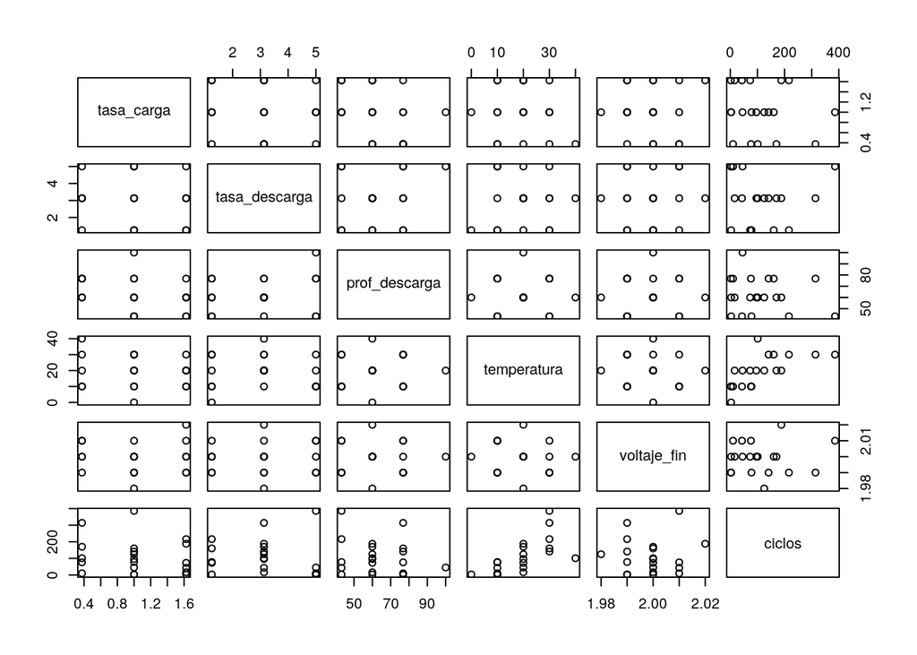